# Cyclistic Bike-Share Case Study

Oluwaseun Otoki

2022-05-08

The following analysis is based on the Google Data Analytics Capstone Case Study “How Does a Bike-Share Navigate Speedy Success?”

## Background

Cyclistic is bike-sharing company with a fleet of 5,824 bicycles that are geotracked and locked into a network of 692 stations across Chicago. The bikes can be unlocked from one station and returned to any other station in the system anytime.

Cyclistic has 3 flexible pricing options: single-ride passes, full-day passes, and annual memberships. Customers who purchase single-ride or full-day passes are casual riders. Customers who purchase annual memberships are Cyclistic members.

## Scenario

You are a junior data analyst working in the marketing analyst team at Cyclistic, a bike-share company in Chicago. The director of marketing believes the company’s future success depends on maximizing the number of annual memberships. Therefore, your team wants to understand how casual riders and annual members use Cyclistic bikes differently. From these insights, your team will design a new marketing strategy to convert casual riders into annual members. But first, Cyclistic executives must approve your recommendations, so they must be backed up with compelling data insights and professional data visualizations.

### Business Task

How do annual members and casual riders use Cyclistic bikes differently?

## Preperation

I am using Cyclistic’s historical trip [dataset](https://divvy-tripdata.s3.amazonaws.com/index.html) to analyze 12 months (April 2021-March 2022), prepared by [Motivate International Inc](https://ride.divvybikes.com/data-license-agreement). R will be used to for data cleaning and visualizations.

**Step 1: Install packages**

```r
library(tidyverse)
library(ggplot2)
library(lubridate)
library(dplyr)
library(janitor)
library(skimr)
```

**Step 2: Import data sets**

```r
trips_2104 <- read.csv('202104-divvy-tripdata.csv')
trips_2105 <- read.csv('202105-divvy-tripdata.csv')
trips_2106 <- read.csv('202106-divvy-tripdata.csv')
trips_2107 <- read.csv('202107-divvy-tripdata.csv')
trips_2108 <- read.csv('202108-divvy-tripdata.csv')
trips_2109 <- read.csv('202109-divvy-tripdata.csv')
trips_2110 <- read.csv('202110-divvy-tripdata.csv')
trips_2111 <- read.csv('202111-divvy-tripdata.csv')
trips_2112 <- read.csv('202112-divvy-tripdata.csv')
trips_2201 <- read.csv('202201-divvy-tripdata.csv')
trips_2202 <- read.csv('202202-divvy-tripdata.csv')
trips_2203 <- read.csv('202203-divvy-tripdata.csv')
```

Compare column names of each file. **Columns must be in the same order for data merging**. Result “0 rows” means there are no discrepancies.

```r
compare_df_cols(trips_2104, trips_2105, trips_2106, trips_2107, trips_2108, trips_2109, trips_2110, trips_2111, trips_2112, trips_2201, trips_2202, trips_2203, return = "mismatch")
```

```
##  [1] column_name trips_2104  trips_2105  trips_2106  trips_2107  trips_2108
##  [7] trips_2109  trips_2110  trips_2111  trips_2112  trips_2201  trips_2202
## [13] trips_2203
## <0 rows> (or 0-length row.names)
```

Inspect the data frames for any inconsistencies

```r
str(trips_2104)
```

```
## 'data.frame':    337230 obs. of  13 variables:
##  $ ride_id           : chr  "6C992BD37A98A63F" "1E0145613A209000" "E498E15508A80BAD" "1887262AD101C604" ...
##  $ rideable_type     : chr  "classic_bike" "docked_bike" "docked_bike" "classic_bike" ...
##  $ started_at        : chr  "2021-04-12 18:25:36" "2021-04-27 17:27:11" "2021-04-03 12:42:45" "2021-04-17 09:17:42" ...
##  $ ended_at          : chr  "2021-04-12 18:56:55" "2021-04-27 18:31:29" "2021-04-07 11:40:24" "2021-04-17 09:42:48" ...
##  $ start_station_name: chr  "State St & Pearson St" "Dorchester Ave & 49th St" "Loomis Blvd & 84th St" "Honore St & Division St" ...
##  $ start_station_id  : chr  "TA1307000061" "KA1503000069" "20121" "TA1305000034" ...
##  $ end_station_name  : chr  "Southport Ave & Waveland Ave" "Dorchester Ave & 49th St" "Loomis Blvd & 84th St" "Southport Ave & Waveland Ave" ...
##  $ end_station_id    : chr  "13235" "KA1503000069" "20121" "13235" ...
##  $ start_lat         : num  41.9 41.8 41.7 41.9 41.7 ...
##  $ start_lng         : num  -87.6 -87.6 -87.7 -87.7 -87.7 ...
##  $ end_lat           : num  41.9 41.8 41.7 41.9 41.7 ...
##  $ end_lng           : num  -87.7 -87.6 -87.7 -87.7 -87.7 ...
##  $ member_casual     : chr  "member" "casual" "casual" "member" ...
```

**Step 3: Data Merging**

Due to the consistency in the data, we are now able to merge our data into a single DataFrame.

```r
city_trips <- bind_rows(trips_2104, trips_2105, trips_2106, trips_2107, trips_2108, trips_2109, trips_2110, trips_2111, trips_2112, trips_2201, trips_2202, trips_2203)
```

Drop the following columns: start_lat, start_lng, emd_lat, end_lng. Data contains station locations already. Coordinates are not needed.

```r
city_trips <- city_trips %>%
  select(-c(start_lat, start_lng, end_lat, end_lng))
```

**Step 4: Adding new variables / Preparing for analysis**

1. Add the date, month, year, day, and the day of the week.

```r
city_trips$date <- as.Date(city_trips$started_at) #Format is yyyy-mm-dd
city_trips$month <- format(as.Date(city_trips$date), "%m")
city_trips$day <- format(as.Date(city_trips$date), "%d")
city_trips$year <- format(as.Date(city_trips$date), "%Y")
city_trips$day_of_week <- format(as.Date(city_trips$date), "%A")
```

2. Add ride the ride length.

```r
city_trips$ride_length <- difftime(city_trips$ended_at,city_trips$started_at)
```

## Analysis

I will be calculating the mean, median, max, and min values to identify trends and differences in behavior between the different customers.

```r
aggregate(city_trips$ride_length ~ city_trips$member_casual, FUN = mean)
```

```
##   city_trips$member_casual city_trips$ride_length
## 1                   casual         1904.4376 secs
## 2                   member          802.1597 secs
```

```r
aggregate(city_trips$ride_length ~ city_trips$member_casual, FUN = median)
```

```
##   city_trips$member_casual city_trips$ride_length
## 1                   casual               946 secs
## 2                   member               562 secs
```

```r
aggregate(city_trips$ride_length ~ city_trips$member_casual, FUN = max)
```

```
##   city_trips$member_casual city_trips$ride_length
## 1                   casual           3356649 secs
## 2                   member             89998 secs
```

```r
aggregate(city_trips$ride_length ~ city_trips$member_casual, FUN = min)
```

```
##   city_trips$member_casual city_trips$ride_length
## 1                   casual             -7082 secs
## 2                   member             -6845 secs
```

```r
aggregate(city_trips$ride_length ~ city_trips$member_casual + city_trips$day_of_week, FUN = mean)
```

```
##    city_trips$member_casual city_trips$day_of_week city_trips$ride_length
## 1                    casual                 Friday         1806.1713 secs
## 2                    member                 Friday          788.3662 secs
## 3                    casual                 Monday         1888.9178 secs
## 4                    member                 Monday          778.1024 secs
## 5                    casual               Saturday         2056.9014 secs
## 6                    member               Saturday          899.5926 secs
## 7                    casual                 Sunday         2244.4810 secs
## 8                    member                 Sunday          920.5760 secs
## 9                    casual               Thursday         1672.9012 secs
## 10                   member               Thursday          754.2513 secs
## 11                   casual                Tuesday         1646.0722 secs
## 12                   member                Tuesday          751.3066 secs
## 13                   casual              Wednesday         1665.9345 secs
## 14                   member              Wednesday          755.3065 secs
```

**Organize the days of the week in order**

```r
city_trips$day_of_week <- ordered(city_trips$day_of_week, levels=c("Sunday", "Monday", "Tuesday", "Wednesday", "Thursday", "Friday", "Saturday"))
```

**View the average ride time for each day by members v casual riders**

```r
aggregate(city_trips$ride_length ~ city_trips$member_casual + city_trips$day_of_week, FUN = mean)
```

```
##    city_trips$member_casual city_trips$day_of_week city_trips$ride_length
## 1                    casual                 Sunday         2244.4810 secs
## 2                    member                 Sunday          920.5760 secs
## 3                    casual                 Monday         1888.9178 secs
## 4                    member                 Monday          778.1024 secs
## 5                    casual                Tuesday         1646.0722 secs
## 6                    member                Tuesday          751.3066 secs
## 7                    casual              Wednesday         1665.9345 secs
## 8                    member              Wednesday          755.3065 secs
## 9                    casual               Thursday         1672.9012 secs
## 10                   member               Thursday          754.2513 secs
## 11                   casual                 Friday         1806.1713 secs
## 12                   member                 Friday          788.3662 secs
## 13                   casual               Saturday         2056.9014 secs
## 14                   member               Saturday          899.5926 secs
```

**View the number of rides and average duration per day by customer type**

```r
city_trips %>%
  mutate(weekday = wday(started_at, label = TRUE)) %>%
  group_by(member_casual, weekday) %>%
  summarise(number_of_rides = n()
            ,average_duration = mean(ride_length/60)) %>%
  arrange(member_casual, weekday)
```

```
## # A tibble: 14 × 4
## # Groups:   member_casual [2]
##    member_casual weekday number_of_rides average_duration
##    <chr>         <ord>             <int> <drtn>
##  1 casual        Sun              482840 37.40802 secs
##  2 casual        Mon              292996 31.48196 secs
##  3 casual        Tue              276375 27.43454 secs
##  4 casual        Wed              286402 27.76557 secs
##  5 casual        Thu              293632 27.88169 secs
##  6 casual        Fri              364282 30.10285 secs
##  7 casual        Sat              550015 34.28169 secs
##  8 member        Sun              387742 15.34293 secs
##  9 member        Mon              439435 12.96837 secs
## 10 member        Tue              490099 12.52178 secs
## 11 member        Wed              499936 12.58844 secs
## 12 member        Thu              475334 12.57086 secs
## 13 member        Fri              453113 13.13944 secs
## 14 member        Sat              431331 14.99321 secs
```

## Visualizations

#### Number of rides per day by customer type

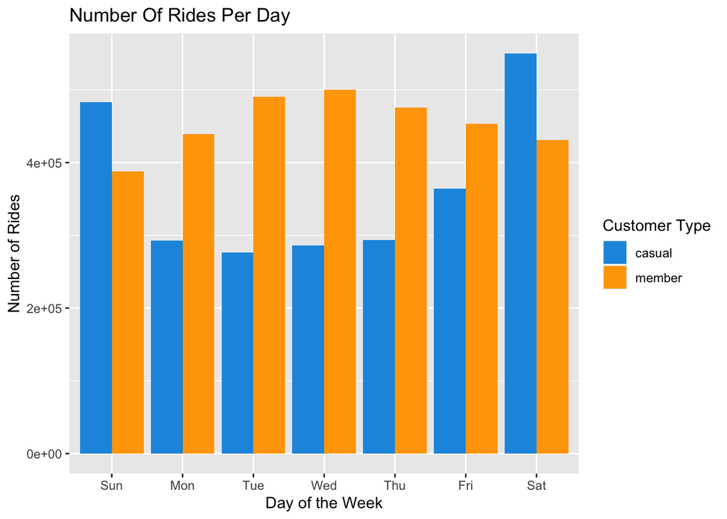

```r
city_trips %>%
  mutate(weekday = wday(started_at, label = TRUE)) %>%
  group_by(member_casual, weekday) %>%
  summarise(number_of_rides = n()
            ,average_duration = mean(ride_length)) %>%
  arrange(member_casual, weekday) %>%
  ggplot(aes(x = weekday, y = number_of_rides, fill = member_casual)) +
  geom_col(position = "dodge") + scale_fill_manual(values = c("casual" = "#1b98e0", "member" = "orange")) + labs(title= "Number Of Rides Per Day",
        x = "Day of the Week", y = "Number of Rides",
        fill = "Customer Type")
```

#### Average trip duration per day by customer type

```
## Defaulting to continuous.
```

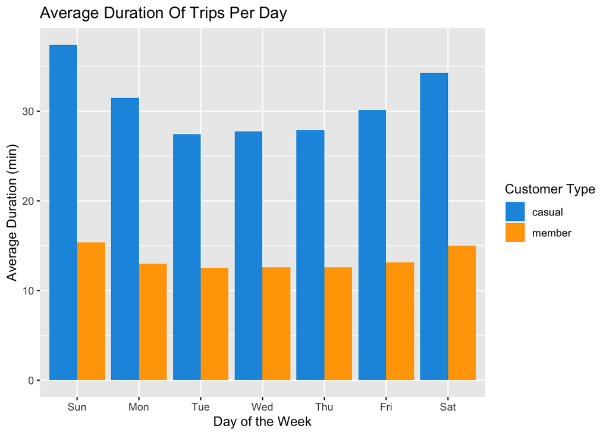

```r
city_trips %>%
  mutate(weekday = wday(started_at, label = TRUE)) %>%
  group_by(member_casual, weekday) %>%
  summarise(number_of_rides = n()
            ,average_duration = mean(ride_length/60)) %>%
  arrange(member_casual, weekday) %>%
  ggplot(aes(x = weekday, y = average_duration, fill = member_casual)) +
  geom_col(position = "dodge") + scale_fill_manual(values = c("casual" = "#1b98e0", "member" = "orange"))+
  labs(title= "Average Duration Of Trips Per Day",
  x = "Day of the Week", y = "Average Duration (min)",
  fill = "Customer Type")
```

## Conclusions

1. Casual riders average more than two times the rate of members in trip duration.
2. Members take more rides than casual customers except on weekends.

## Recommendations

1. Since casual riders average longer trips, increase their trip rate, which will incentivize them to switch to a member with lower trip rates.
2. Develop member incentives such as store promotions or weekend promotions where the casual riders usually peak.